# Definitions

## What is a Model?

A model, or more precisely, an *engineering model*, is a representation of something we want to understand. The word *representation* here means that while a model *represents* something real, and can even predict the behavior of that real thing quite accurately, it is **not the same as the real thing.** A model airplaine is a good example of a *physical model* of what we would call a "true" airplane that carries people and cargo over long distances. While it shares some features of the real airplane, it is different in some fundamental ways, such as its power source, size, and flight time. It cannot do everything that a real airplane can do... but it does enough things similarly enough that we might better understand how real airplanes work and/or how they should be built by building a model.

An *engineering model* can be physical, like a model airplane, or it may not be. What makes a model an *engineering model* is its utility for designing and/or understanding the thing it is supposed to represent.

The engineering models we will be building in this class will rarely (if ever) be physical models. They will mostly be comprised of **mathematical equations** that help us predict the behavior of physical things or processes that we wish to build or understand. The mathematical equations representing the thing or process we wish to understand will, if we do our jobs correctly, allow us to predict what will happen when something changes.

This ability to "predict" using a model is fundamental to engineering. If engineers needed to simply change design elements randomly, building full-sized airplanes over and over until one worked "just right," engineering as a discipline would be incredibly dangerous, expensive, and inefficient. Using mathematical equations to tell us what will happen when we build a design or implement a policy can allow us to avoid many costly and dangerous mistakes that would result from a "trial and error" approach.

Link to Original Context in: Reading_01

## What is a System?

Link to Original Context in: Reading_01

A **system** refers to any collection of items, pieces, or subprocesses that we call **elements**. These elements interact to produce a behavior we are interested in understanding and/or predicting. A system is generally described as an "isolated slice" of the universe. Anything inside that "slice" is part of the system. Anything outside of that "slice" is called the system's "environment," or its surroundings.

This means that while a system may exchange energy, material, and/or information with things that are outside of its boundaries, changes in the system's behavior are generally driven by its environment, rather than the other way around.

**Elements** are the "atomic units" of a system. They can be either *processes*, *physical objects,* or *collections* of physical objects. Their relevant behavior can be represented completely by an equation or set of equations describing how they interact with either other elements in the system or with the system's surroundings.

Elements could, in theory, be modeled as "systems" themselves, with their own sets of interacting elements. However, when we declare that something is to be considered an "element" in a system, it means that we are not interested in unpacking its behavior or construction any further.

For example, a bus could be considered an "element" in a *transportation system.* The bus itself could be modeled as a system comprised of elements like wheels, springs, an engine, and so on. However, when we say that the bus is an **element** in our transportation system, it means that we are considering the bus to be an irredicible building block in our definition of the transportation system. Perhaps this bus's behavior of interest could be modeled using only an equation relating the time of day and a "traffic congestion factor" to its position along a route.

It's true that this is a bold simplification of a bus's behavior. By making the declaration that this bus's position is the only thing we care about, and that this position can be known using only two independent variables, we are **assuming a lot.** We are **ignoring a lot.** What if the bus breaks down? Why don't we care about how it bounces over potholes, or how much fuel it uses?

Well, we **can't** model **everything**. When we decide to consider building a model of the "transportation system," we must immediately begin *simplifying reality.* We have to decide where the system (as we define it) begins and ends, and what level of complexity is required to know what we need to know about the system.

This leads us to a pair of fundamental truths about engineering models:

1. All models are *wrong* because they do not include every nuance of every phenomenon that may impact a system's behavior
2. Good models a *useful* because they sufficiently *predict* the system's behavior. They are still "wrong" in the sense that there are phenomena they will either ignore or predict inaccurately, but they are "accurate enough."

Building good models is the goal, and in ES103, we will use a simple three-step process to build a model.

# System Scoping

## Model Scoping

Link to Original Context in: Reading_01

When we attempt to model a phenomenon or series of interconnected phenomena as a "system," we are looking for a collection of elements that interact with each other and the system's surroundings to produce the behavior we are interested in understanding. Defining the boundary that indicates what is "inside" the system and what is not is what we will call **model scoping.** The process of "scoping" a system model involves drawing the system boundary, and answering the following three questions:

1. What quantities (energy, material, information) go *in* to the system boundary that are relevant to the behavior we're interested in?
2. What quantities (energy, material, information) go *out* of the system boundary that are relevant to the behavior we're interested in?
3. What quantities (energy, material, information) are *stored within the system boundary?*

## Energetic Diagrams

For this course, an energetic diagram will be defined as a diagram that **explicitly shows how we will model energy that is exchanged between the system (or a subsystem or an element) and its environment.** "How we will model" is important here. In drawing certain arrows that represent energy transfer, we will often make assumptions about *how* this energy is transferred and *with what.* Because these will often be simplifications, it is important to keep in mind that the energetic diagram is not "truth" by default. It is a model.

Arrows pointing in to the system should reflect outside influence from the system's surroundings that would *increase* its energy in the absence of other factors. These influences could be in the form of either heat or work as a function of time. Arrows pointing out of the system should reflect work or heat that a system transfers *to* its environment. In the absence of other factors, an outward-pointing arrow would decrease the amount of energy stored within a system.

More specifically, arrows represent a *flow of power* between a system and its surroundings, which can either be a known subsystem that is also being modeled, or a system's unmodeled, external surroundings ('the universe,' for instance). An example for an arbitrary system is shown below:

Link to Original Context in: Reading_09

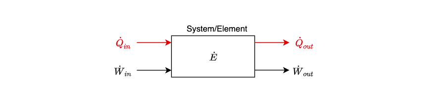

## Independent Energy Storage Elements and System Order

In a lumped-element model of an engineering system (such as those we have been building, where each element in the system scope either stores or dissipates energy), the number of *significant, independent* energy storage elements is equal to the number of derivatives required to model the system.

For example, a single differential equation representing a model of a system that has 3 different energy storing elements would need to have a triple derivative of the output, a double derivative of the output, and a single derivative of the output in the equation in order to fully describe the system behavior. This is because each derivative is a representation of how the energy in the total system (consisting of 3 energy storage elements) can change.

**Note: recall that all "real" systems have effectively infinite numbers of energy-storing elements. The question is never how many energy-storing elements a system *truly* has, but always how many of those are *significant enough* to include in our model**.

Link to Original Context in: Reading_17

## Dependence and Independence of Energy Storage Elements

Two elements in a system model are *independent* of one another if the energy stored in one element *cannot* be directly written as a function of the energy in another. Two or more elements are *dependent* when Their energy storage equations can be directly related. This often occurs if the two elements are *directly in series* or *directly in parallel* in an equivalent circuit representation, and in *some cases* when two energy storing elements are connected by a transducer with no dissipative elements in between them.

Link to Original Context in: Reading_17

# Model Construction

## Model Construction

Link to Original Context in: Reading_01

Model Construction is the process of building the equation(s) that represent the behavior of the system we defined in the "Model Scoping" step.

Model Construction varies a lot by sub-discipline in engineering, but it can be reduced to the following general procedure:

1. Define the model's *independent variables*. These are quantities that are **known** before the model's equations are evaluated. They may be physical parameters like mass, they may be parameters that characterize a process, such as death rate. They may be quantities that vary in a known way, such as time or a spatial coordinate. A model's independent variables are often called "inputs" if they are quantities that may vary with space or time, and often called **parameters** if they are unchanging.
2. Define the model's *dependent variables*. These are quantities that *result* from the interactions between system elements and either one another or the system's surroundings. The dependent variables nearly always describe the phenomena your system is supposed to predict. A model's dependent variables are often called "outputs."
3. Use a disciplined process to relate the model's independent variables to its dependent variables.

Step 3 is probably the most complex of the three, and it is the one that can differ wildly from discipline to discipline. For example, the way an environmental engineer goes from a list of model inputs and outputs to a final equation will be quite different from the way a mechanical engineer might accomplish the same goal.

The processes used to actually relate a model's inputs to its outputs might be the use of an empirical relationship, or perhaps Newton's laws, or perhaps the conservation of energy. We will focus on only a small subset of the methods for model construction in this course, but for us, step 3 involves rigorously defining our system's *elements*, how each behaves, and how each interacts with the others.

It is in this step that you will need to decide what level of detail you will use to represent each of the elements in your system scope. Simple is often a good place to start! If, when you *evaluate* your model, you find its accuracy lacking, you may consider increasing the level of detail with which you represent each element, or whether the system scope you chose was appropriate.

## Model Construction: Kinematics for translational motion

Link to Original Context in: Reading_02

*Kinematics* refers to the study of motion. When we talk about translational motion, which means the motion of an object that is not rotating, we usually talk about an object's position, velocity, and acceleration. These quantities are related to one another! We often say that an object's velocity is *how far it goes in a certain amount of time*. Formally, an object's velocity is the *instantaneous* change in its position with respect to time. This is also referred to as the *derivative* of position with respect to time, and is written as follows:

$$\vec{v} = \frac{d}{dt} \vec{x}$$

We will save the formal definition of a derivative for later when the formality is warranted. What we need first is simply an *intuitive* understanding of the derivative. If you do not already have an intuitive understanding of derivatives (perhaps you have not yet had calculus!), just think of a derivative of $x$ with respect to time as an equation (or a second plot) representing the *slope* of the $x$ vs. $t$ plot. See the plot of position and velocity vs. time below.

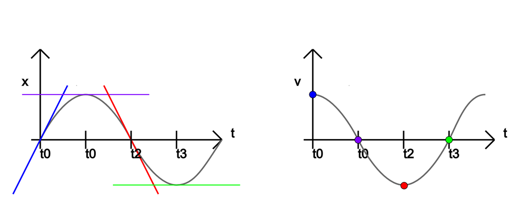

In a similar fashion, we can say that an object is *accelerating* if its velocity is changing. Therefore, we can also write acceleration's relationship to position as a derivative:

$$\vec{a} = \frac{d}{dt} \vec{v}$$

Once again, the derivative of velocity with respect to time represents the *slope* of the velocity vs. time plot at any particular time. Asking "what is my acceleration right now?" is the same as asking "at this very instant, how is my velocity changing?

## Model Construction: Basics of 2-D Vectors in Cartesian Coordinates

Link to Original Context in: Reading_02

In engineering, we represent any quantity that has both a size and a direction as a *vector*. Consider a boat traveling across the ocean from New York to London. If we represent East as the X direction, North as the Y direction, and look down on the boat from the sky, we might represent (or *model*) the boat's travel using the following picture.

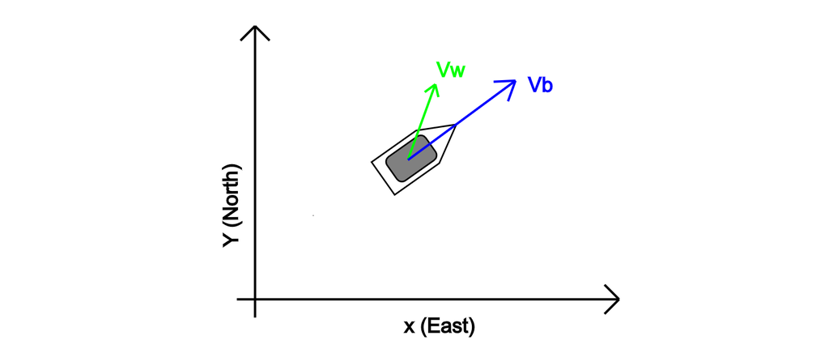

The boat's speed relative to the water due to its engine is given by the *scalar* quantity $v_b$, which does not specify its direction but only how fast the boat is going. We write $\vec{v}_b$ to indicate the boat's *velocity* as a vector quantity that has a particular direction. The boat is also moved relative to a fixed location on earth by currents in the water. The contribution of those currents to the boat's overall velocity can be written as $\vec{v}_w$. So what is the boat's total velocity? It is: $$\vec{v}_t = \vec{v}_b + \vec{v}_w$$

But if you can imagine this scenario in your head, you probably can intuit that **this is not the same** as writing the scalar equation: $$v_t = v_b + v_w$$

Because the water's velocity and the boat's velocity relative to that water are in *different directions*, so the boat's actual direction of motion will be somewhere in between the direction of $v_w$ and the direction of $v_b$. So how do we add vectors? By definition, vectors can be added using the *paralellogram law*, which is shown graphically below.

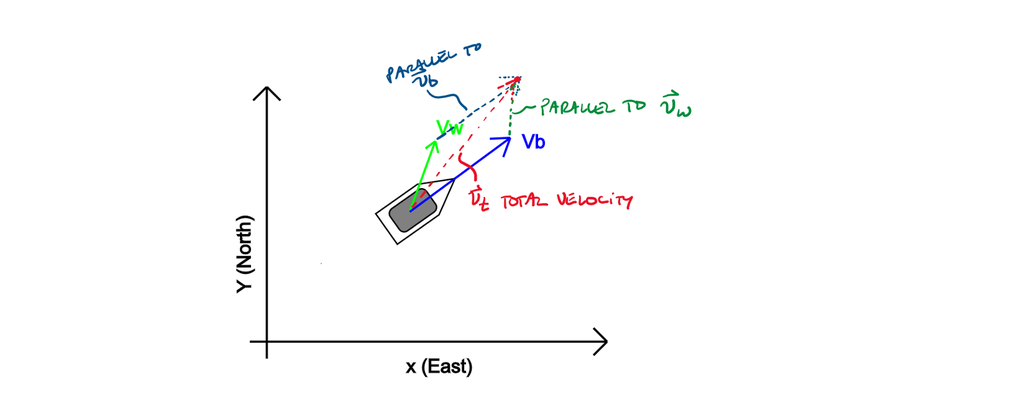

Thankfully, one of the fundamental consequences of paralellogram addition is that it allows us to break any vector up into *components,* or pieces, that are parallel to the axes we are interested in. In this case, that would be East (X) and North (Y). Let's try this for the velocity vector of the boat relative to the water, $\vec{v_b}$.

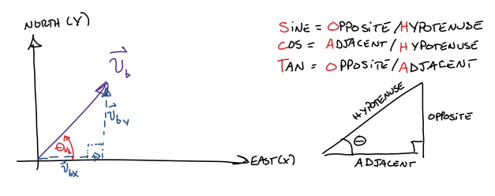

As the picture shows, we can imagine that the vector $\vec{v}_b$ is made up of two smaller vectors that are conveniently aligned with our X and Y axes. If we knew the magnitude $v_b$, we would then be able to see what the *magnitudes* of $\vec{v}_{bx}$ and $\vec{v}_{by}$ were by using the right triangle formed by aligning the component vectors "tip to tip" so that they end up at the arrow head of the total velocity of the boat relative to the water, $\vec{v}_b$. Using the mnemonic "SOH-CAH-TOA," reproduced to the right of our vector figure, we find that:

$$v_{bx} = v_b \cos \theta_{vb}$$$$v_{by} = v_b \sin \theta_{vb}$$

The pythagorean theorem combined with a quick trigonometric identity shows handily that the magnitude of $\vec{v}_b$, which we write as $v_b$, can be found as:

$$v_b = \sqrt{v_{bx}^2+v_{by}^2}$$

We can also write $\vec{v}_b$ in terms of these components when we consider that the "arrows" representing the size of the components can be expressed as vectors themselves:

$$\vec{v}_b = v_{bx}\hat{\imath} + v_{by} \hat{\jmath}$$

Where $\hat{\imath}$ is a "unit vector" of length 1 in the X-direction, which is scaled by $v_{bx}$, and $\hat{\jmath}$ is a "unit vector" of length 1 in the Y-direction, which is scaled by $v_{by}$. Generally speaking, the "hat" on top of a letter designates it as a unit vector (a vector with length 1).

Resolving *all* vectors of interest in our problem into components for a common set of axes in the fashion described above allows us to use scalar, rather than vector addition to find out what the *components* of $\vec{v}_t$ in the X and Y directions are. Once we have them, we could use them in a model to predict the boat's Northing and Easting position as functions of time. In this example, the total velocity for the boat, $\vec{v}_t$, can be written as follows:

$$ \vec{v}_t = v_{tx} \hat{\imath} + v_{ty} \hat{\jmath} $$

And each component can be found by summing the components of $\vec{v}_{b}$ and $\vec{v}_w$ in the X and Y directions:

$$v_{tx} = v_{bx} + v_{wx}$$$$v_{ty} = v_{by} + v_{wy}$$

## Model Construction: Newton's Laws

One of the ways you are probably already familiar with building models for physical phenomena, perhaps from high school, is using Newton's Laws. We will actually use them extensively in this course as well! Newton's laws, applied to *rectilinear motion and linear momentum* are paraphrased below:

### Newton's First Law

If a frame of reference is *inertial*, an object will either remain at rest or move at constant velocity unless it is subjected to a nonzero net force. This can be written as "A net zero force implies no acceleration," which is represented by the equation:

$$ \Sigma \vec{F} = 0 \rightarrow \frac{d}{dt} \vec{v} = \vec{a} = 0$$

Notice that Force $\vec{F}$ is a vector quantity, meaning that it has both a magnitude and a direction, just like velocity and acceleration do.

Link to Original Context in: Reading_02

### Newton's Second Law

The change in momentum of an object is directly proportional to the force applied. Changes in momentum occur in the *direction* of the net applied force. This can be written as the equation:

$$\Sigma \vec{F} = \frac{d}{dt} (m\vec{v})$$

If an object's mass is constant, the term $m$ can be pulled out of the derivative on the right-hand side, and the second law takes its more familiar form:

$$\Sigma \vec{F} = m\vec{a}$$

Link to Original Context in: Reading_02

### Newton's Third Law

Forces between objects are equal in magnitude, but opposite in direction. This is one of the most helpful things to remember when constructing *free body diagrams* of objects that you wish to apply the second law to. If body A exerts a force $\vec{F}_{AB}$ on body B, then this is equal and opposite to the force $\vec{F}_{BA}$ that body B exerts on body A. Thus, we can write:

$$\vec{F}_{AB} = - \vec{F}_{BA}$$

Link to Original Context in: Reading_02

## Model Construction: Free Body Diagrams (FBDs)

Link to Original Context in: Reading_02

Using Newton's Laws for model construction often means determining the *motion* of an object when it is subjected to forces from the outside world, or in some cases, forces exerted on one element of a system by another. This can get complex very quickly, but the "Free Body Diagram" can help. A Free Body Diagram, or FBD, is a diagram in which one physical body is presented *on its own*, and all forces applied to the object are drawn on top of it as *vectors*.

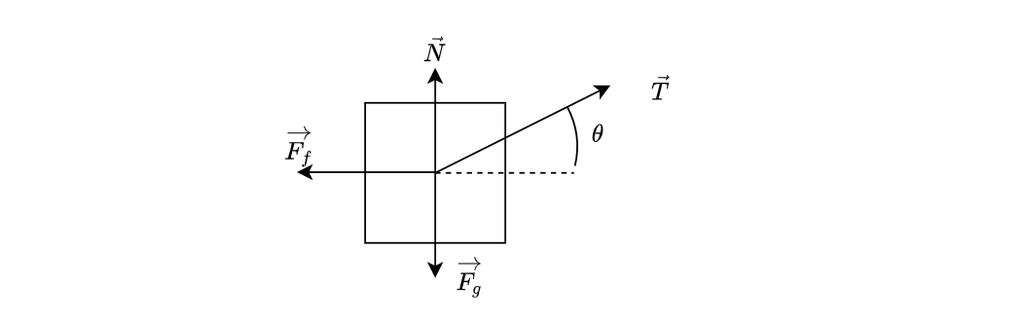

## Model Construction: Constructing a model for translational motion using an FBD

Newton's Second Law tells us that the net applied force on an object is what causes it to accelerate. Acceleration causes velocity to change, and velocity causes position to change. The FBD is what tells us *what the net force on an object actually is*, and to calculate it, we use the diagram to *add up the vectors representing all forces applied to the object*. This allows for a specific sum of forces to fill in the left-hand side of the Newton's second law equation:

$$\Sigma \vec{F} = m \vec{a}$$

Link to Original Context in: Reading_02

## Calculating position and velocity under constant acceleration

Because of the relationships between position, velocity, and acceleration:

$$\vec{a} = \frac{d}{dt} \vec{v}$$$$\vec{v} = \frac{d}{dt} \vec{x}$$

We can derive a special set of equations that can be used to calculate an object's position and velocity **in situations where acceleration is constant in both magnitude and direction**. These equations are based on the *rules of integration*. We will be more formal and deliberate with the concept of integration in a future discussion, but for now, think of an integral as an anti-derivative. In other words, if

$$\vec{a} = \frac{d}{dt} \vec{v}$$

Then, with the definition of the integral (which we denote by the symbol $\int$), we can say that: $$\vec{v} = \int \vec{a} dt$$ Likewise, if: $$\vec{v} = \frac{d}{dt} \vec{x}$$ Then, by the same definition, $$\vec{x} = \int \vec{v} dt$$

Where the subscript "0" indicates the position or velocity of the object at time $t=0$. Using the same relationship and notation for the corresponding y-component of acceleration, we could write:

$$v_y (t) = v_{y0} + a_y t$$$$y(t) = y_0 + v_{y0} t + \frac{1}{2} a_y t^2$$

Link to Original Context in: Reading_02

## Empirical Models

Link to Original Context in: Reading_03

A purely empirical model is one that is derived using data. The inner workings of the relationships between system inputs and outputs may be unknown, but using *past knowledge* of the behavior of a system (or sometimes, just one element in a system), the future of the same system or element can be predicted.

Empirical models are often used in the early stages of modeling, when the behavior of a system or element is mysterious. They can also be used in situations where it is unlikely that a principled physical model for a system or element's behavior will be accurate, or when it is practically impossible to obtain.

### Empirical Models: Lookup Table

Link to Original Context in: Reading_03

The simplest form of a "model" that is based on past experience is what we call a *lookup table*. This is no different than the original, collected data itself. The idea is that "if the system acted this way once, perhaps it will act similarly the next time we run the experiment." Let's look at an example in the MATLAB/Octave language. Say you had data for a model that related time $t$ to some output $y$. You collected data in a table that looks like the following:

| **$t$** | **$y$** |
| --- | --- |
| 0 | 10 |
| 0.5 | 10.09 |
| 1 | 10.264 |
| 1.5 | 10.442 |
| 2 | 10.594 |
| 2.5 | 10.713 |
| 3 | 10.801 |
| 3.5 | 10.864 |
| 4 | 10.908 |
| 4.5 | 10.939 |
| 5 | 10.96 |
| 5.5 | 10.973 |
| 6 | 10.983 |
| 6.5 | 10.989 |
| 7 | 10.993 |
| 7.5 | 10.995 |
| 8 | 10.997 |

You can plot the data in MATLAB quite easily, as shown in the cell below.

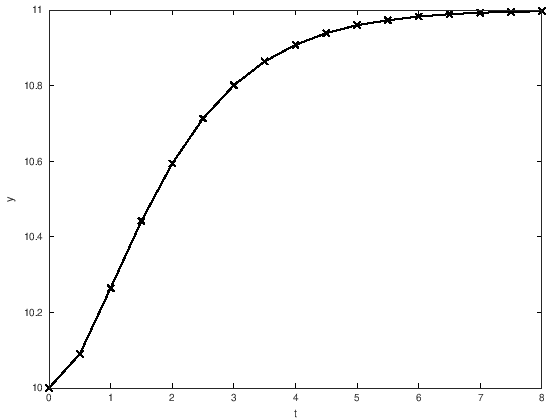

```matlab
t = [0 0.5 1 1.5 2 2.5 3 3.5 4 4.5 5 5.5 6  6.5 7 7.5 8]'; %the ' at the end means 'transpose,' or turn rows into columns. Makes this a "tall" array.
y = [ 10 10.09 10.264 10.442 10.594 10.713 10.801 10.864 10.908 10.939 10.96 10.973 10.983 10.989 10.993 10.995 10.997]'; %see comment above.

plot(t,y,'kx-','linewidth',4)
xlabel('t')
ylabel('y')
```

Then, let's say I suspected that this behavior would be the same every time I collected similar data.

If these assumptions were correct, and I needed to answer the question:

**If $y$ begins at 10.594 in a new experiment, what will the value of $y$ be three seconds later?**

I could do this. If I look at either the table of data or the plot itself, I can see that in my original data, $y=10.594$ when $t=2.0$. To find out what $y$ would be three seconds later than that, I would simply need to look at my table to see what value $y$ takes at $t=5$ in my original table (three seconds later than $t=2$). If I looked in the table, I could plainly see that the answer I'm looking for is $y=10.96$!

This is the basic idea of a lookup table. These are actually used in practice in many branches of engineering, including thermodynamics and heat transfer. They're also used in your car, to tell the computer how much fuel is needed for a given combination of RPM and throttle position. They are helpful when a "closed form" mathematical equation is either practically impossible or too computationally intensive to obtain.

## Linear Interpolation

Link to Original Context in: Reading_03

*interpolation* is the process of *inferring* the value of a dependent variable (output) given a table of data consisting of independent and dependent variable pairs. Consider the following data set, in which pairs of time and y values were collected. We can infer what the value of would be *in between* two data points collected at times $t_4$ and $t_5$ by assuming that the value of $y$ varies *linearly* in between these two points. While this is probably not strictly true, it is often a good approximation if the time difference between $t_4$ and $t_5$ is small relative to how fast $y$ changes.

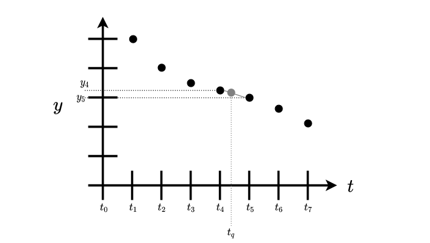

In the picture above, $t_q$ is a point in beytween $t_4$ and $t_5$ where we wish to approximate the corresponding value of the output $y$ by assuming that $y$ follows the shape of a line in between the two known data points $(t_4,y_4)$ and $(t_5,y_5)$.

$$ y = m(t-t_4) + y_4$$

Where the slope $m$ is given by "rise over run" in the equation:

$$m = \frac{y_5-y_4}{t_5-t_4}$$

All together, this means that the value we wish to approximate can be found using:

$$ y(t_q) = \frac{y_5-y_4}{t_5-t_4}(t_q-t_4) + y_4 $$

In MATLAB/Octave, there is a function called "interp1" that does this procedure for you. To learn how to use it, type "help interp1" into a code cell in the Jupyter notebook or on a MATLAB command prompt.

## Linear Extrapolation

Link to Original Context in: Reading_04

Extrapolation is the act of estimating a variable's value beyond the variable's original observation range. The simplest way to do this is by assuming that after a system's behavior leaves the boundaries of the original lookup table, it continues to progress as a linear function with the equation of the line defined by the last two points in the table.

In linear *interpolation*, we used the *slope* of the line in between two points in our lookup table to infer the value of a dependent variable *in between those two points.* In *linear extrapolation,* we use the slope between two points on our plot to infer what lies *beyond* them. This is shown graphically below.

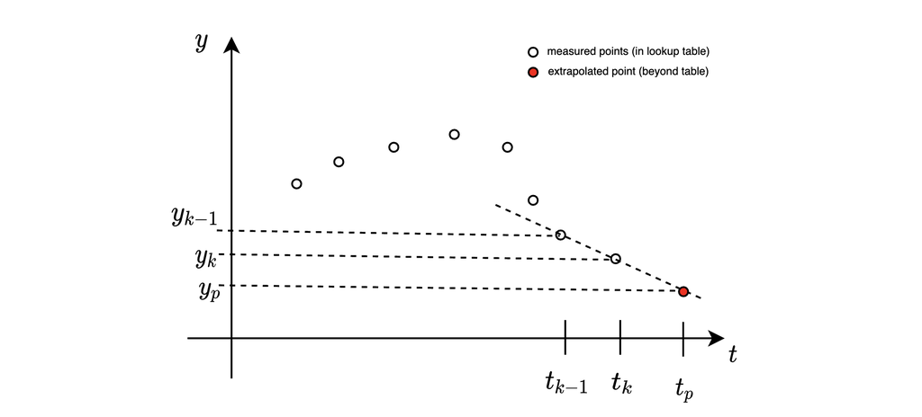

predicting the value of $y$ at time $t_p$ using linear extrapolation means using the values of $y(t_{k-1})$ (the second to last point in the dataset) and $y(t_k)$ (the last point in the dataset) to write the equation of a line between the two points. Then, following that line out to time $t_p$ gives us an estimate for $y(t_p)$. Mathematically, we can write this in point-slope form as:

$$ y(t_p) = y_p = m(t_p-t_k) + y(t_k)$$

Where the slope $m$ is given by: $$ m = \frac{y_k-y_{k-1}}{t_k-t_{k-1}}$$

Putting these two equations together yields our total equation for extrapolation as:

$$y(t_p) = y_p = \frac{y_k-y_{k-1}}{t_k-t_{k-1}}(t_p-t_k)+y(t_k)$$